# A1 - Preproceso de datos

Oscar Pedreño Fernandez

2023-04-03

- *Sacar el documento en html, en pdf tengo un problema con los márgenes de las chunks. No puedo solucionarlo, en HTML el formato sale correctamente.*

# 1. Lectura de datos y examinación del tipo de variable

## 1.1 Cargar el archivo de datos

```r
happiness <- read.csv('Happiness.csv')
```

## 1.2 Examinar el tipo de datos

Para realizar este apartado usamos la función str, que nos indica la estructura de nuestro dataset junto al número de registros, número de variables y tipo de éstas.

```r
str(happiness)
```

```
'data.frame':   157 obs. of  12 variables:
 $ Country                  : chr  "denmark   " "switzerland" "iceland" "  norway" ...
 $ Region                   : chr  "  WESTERN EUROPE" "  WESTERN EUROPE" "WESTERN EUROPE   " "  WESTERN EUROPE" ...
 $ Happiness.Rank           : int  1 61 3 4 5 6 7 8 9 10 ...
 $ Happiness.Score          : chr  "7.526" "7,509" "7.501" "7.498" ...
 $ Lower.Confidence.Interval: num  7.46 7.43 7.33 7.42 7.35 ...
 $ Upper.Confidence.Interval: num  7.59 7.59 7.67 7.58 7.47 ...
 $ GDP.per.Capita           : chr  "1.44178" "1.52733" "1.42666" "1.57744" ...
 $ Family                   : num  1.16 1.15 NA 1.13 1.13 ...
 $ Life.Expectancy          : num  0.795 0.863 0.867 0.796 0.811 ...
 $ Freedom                  : num  0.579 0.586 0.566 0.596 0.571 ...
 $ Government.Corruption    : num  0.445 0.412 0.15 0.358 0.41 ...
 $ Generosity               : num  0.362 0.281 0.477 0.379 0.255 ...
```

Como podemos observar, tenemos tres tipos de variables en nuestro dataset. Identificamos que el tipo de las variables no nos encaja en su totalidad, el tipo correcto de variables debería ser:

- Character → Datos de tipo carácter
  - Country
- Factor → Cualiitativa Nominal
  - Region
- Integer → Valores Enteros: Cuantitativos discretos
  - Happiness.Rank
- Numeric → Cuantitativa continua
  - Lower.Confidence.Interval
  - Upper.Confidence.Interval
  - Family
  - Freedom
  - Government.Corruption
  - Generosity
  - Happiness.Score
  - GDP.per.Capita

# 2. Normalización de las variables cuantitativas

## 2.1 Cambiar el nombre de las variables

Siguiendo el patrón comentado en el enunciado, cambiamos el nombre de las variables usando la función **colnames()**^

```r
colnames(happiness) <- c('Country', 'Region', 'HR', 'HS', 'LCI', 'UCI', 'GpC', 'Family', 'LE', 'Freedom', 'GC', 'Generosity')
```

Para realizar este cambio, mediante la función colnames le pasamos todos los valores de las columnas del dataframe, tanto las que ya estaban correctas como las nuevas.

## 2.2 Variables HS, GpC y Freedom

Procedemos a identificar que sucede con las variables en cuestion.

### Variable HS → Happiness.Score

```r
head(happiness$HS)
```

```
[1] "7.526" "7,509" "7.501" "7.498" "7.413" "7.404"
```

Como podemos observar en esta variable vemos diferentes problemas:

#### 1. El separador decimal esta mezclado, en algunos casos se usa el punto y en otros la coma. En R identificamos el separador decimal con un punto.

Para realizar este cambio vamos a usar la función **sub()** de la siguiente forma:

```r
happiness$HS <- sub(',', '.', happiness$HS)
head(happiness$HS)
```

```
[1] "7.526" "7.509" "7.501" "7.498" "7.413" "7.404"
```

#### 2. La variable es de tipo character, cuando debería ser de tipo numeric (Cuantitativa continua)

```r
class(happiness$HS)
```

```
[1] "character"
```

```r
happiness$HS <- as.numeric((happiness$HS))
class(happiness$HS)
```

```
[1] "numeric"
```

```
[1] "2, 9, 27, 35, 44, 48, 52, 59, 61, 72, 114, 117, 121, 140, 156"
```

### Variable GpC → GDP.per.Capita

```r
tail(happiness$GpC)
```

```
[1] "0.32846" "0.39499" "0.38227" "0.28123" "0.74719" "0,06831"
```

Vemos que nos sucede lo mismo en la variable GpC, por lo que procedemos a hacer las mismas transformaciones:

#### 1. El separador decimal esta mezclado, en algunos casos se usa el punto y en otros la coma. En R identificamos el separador decimal con un punto.

```r
happiness$GpC <- sub(',', '.', happiness$GpC)
tail(happiness$GpC)
```

```
[1] "0.32846" "0.39499" "0.38227" "0.28123" "0.74719" "0.06831"
```

#### 2. La variable es de tipo character, cuando debería ser de tipo numeric (Cuantitativa continua)

```r
class(happiness$GpC)
```

```
[1] "character"
```

```r
happiness$GpC <- as.numeric((happiness$GpC))
class(happiness$GpC)
```

```
[1] "numeric"
```

```
[1] "8, 9, 13, 24, 31, 35, 46, 67, 73, 86, 89, 98, 102, 105, 106, 113, 127, 133, 141, 142, 147, 148, 157"
```

### Variable Freedom

En el caso de la variable Freedom no detectamos ningún tipo de necesidad de transformación, el valor que toman los diferentes países para esta variable es el adecuado.

```r
head(happiness$Freedom)
```

```
[1] 0.57941 0.58557 0.56624 0.59609 0.57104 0.57370
```

```r
class(happiness$Freedom)
```

```
[1] "numeric"
```

# 3. Normalización de las variables cualitativas

## 3.1 Revisad la variable Country

```r
head(happiness$Country)
```

```
[1] "denmark   "  "switzerland" "iceland"     "  norway"    "  finland"
[6] "canada   "
```

Denotamos varios problemas en la variable Country:

#### 1. El texto de los paises contiene espacios en blanco al inicio y final de las palabras.

Procedemos a removerlo con la función **trimws()**

```r
happiness$Country <- trimws(happiness$Country)
head(happiness$Country)
```

```
[1] "denmark"     "switzerland" "iceland"     "norway"      "finland"
[6] "canada"
```

```
[1] "1, 4, 5, 6, 8, 9, 11, 27, 30, 31, 33, 34, 35, 39, 42, 44, 45, 49, 51, 53, 54, 56, 57, 60, 64, 65, 66, 67, 68, 70, 72, 74, 76, 81, 83, 84, 85, 86, 88, 89, 90, 91, 92, 93, 94, 96, 97, 104, 107, 108, 109, 110, 120, 121, 124, 125, 126, 134, 138, 140, 141, 143, 144, 145, 146, 150, 151, 152, 153, 154…
```

#### 1. La primera letra de cada palabra debe estar en mayúscula

Usamos str_to_title de la librería stringr:

```r
library(stringr)
```

```r
happiness$Country <- str_to_title(happiness$Country)
head(happiness$Country)
```

```
[1] "Denmark"     "Switzerland" "Iceland"     "Norway"      "Finland"
[6] "Canada"
```

## 3.2 Revisar la variable Region

```r
table(happiness$Region)
```

```
          CENTRAL AND EASTERN EUROPE        CENTRAL AND EASTERN EUROPE
                                   9                                    2
                     EASTERN ASIA             LATIN AMERICA AND CARIBBEAN
                                   1                                    3
      LATIN AMERICA AND CARIBBEAN      MIDDLE EAST AND NORTHERN  AFRCA
                                   3                                    2
     MIDDLE EAST AND NORTHERN AFRICA                    SOUTHEASTERN ASIA
                                   4                                    1
                SOUTHEASTERN ASIA                           SOUTHERN ASIA
                                   2                                    2
               SUB-SAHARAN  AFRCA                      SUB-SAHARAN AFRICA
                                   5                                    9
                      WESTERN EUROPE                    WESTERN EUROPE
                                   8                                    1
           AUSTRALIA AND NEW ZEALAND           CENTRAL AND EASTERN EUROPE
                                   2                                    8
       CENTRAL AND EASTERN EUROPE                            EASTERN ASIA
                                  10                                    2
                     EASTERN ASIA             LATIN AMERICA AND CARIBBEAN
                                   3                                   11
      LATIN AMERICA AND CARIBBEAN      MIDDLE EAST AND NORTHERN  AFRCA
                                   7                                    3
     MIDDLE EAST AND NORTHERN AFRICA                        NORTH AMERICA
                                  10                                    2
                   SOUTHEASTERN ASIA                 SOUTHEASTERN ASIA
                                   5                                    1
                       SOUTHERN ASIA                     SOUTHERN ASIA
                                   4                                    1
               SUB-SAHARAN  AFRCA                      SUB-SAHARAN AFRICA
                                   8                                   16
                      WESTERN EUROPE                    WESTERN EUROPE
                                   9                                    3
```

### 3.2.1 Quitar espacios en blanco a comienzo y a final:

Para realizar esta tranformación usaremos **trimws()**

```r
happiness$Region <- trimws(happiness$Region)
table(happiness$Region)
```

```
      AUSTRALIA AND NEW ZEALAND      CENTRAL AND EASTERN EUROPE
                              2                              29
                   EASTERN ASIA     LATIN AMERICA AND CARIBBEAN
                              6                              24
MIDDLE EAST AND NORTHERN  AFRCA MIDDLE EAST AND NORTHERN AFRICA
                              5                              14
                  NORTH AMERICA               SOUTHEASTERN ASIA
                              2                               9
                  SOUTHERN ASIA              SUB-SAHARAN  AFRCA
                              7                              13
             SUB-SAHARAN AFRICA                  WESTERN EUROPE
                             25                              21
```

```
[1] "1, 2, 3, 4, 5, 7, 15, 16, 18, 21, 24, 25, 27, 28, 29, 30, 31, 32, 35, 36, 44, 46, 47, 49, 52, 53, 55, 56, 58, 60, 61, 62, 63, 65, 66, 67, 70, 71, 72, 73, 74, 77, 78, 81, 83, 87, 88, 89, 90, 91, 92, 96, 97, 98, 99, 102, 103, 104, 106, 107, 109, 111, 112, 117, 119, 120, 121, 122, 123, 126, 127, 1…
```

### 3.2.2 Corregir “AFRCA” por “AFRICA”:

Para realizar esta transformación usaremos la función **sub()**

```r
happiness$Region <- sub('AFRCA', 'AFRICA', happiness$Region)
table(happiness$Region)
```

```
       AUSTRALIA AND NEW ZEALAND       CENTRAL AND EASTERN EUROPE
                               2                               29
                    EASTERN ASIA      LATIN AMERICA AND CARIBBEAN
                               6                               24
MIDDLE EAST AND NORTHERN  AFRICA  MIDDLE EAST AND NORTHERN AFRICA
                               5                               14
                   NORTH AMERICA                SOUTHEASTERN ASIA
                               2                                9
                   SOUTHERN ASIA              SUB-SAHARAN  AFRICA
                               7                               13
              SUB-SAHARAN AFRICA                   WESTERN EUROPE
                              25                               21
```

```
[1] "28, 66, 67, 78, 106, 111, 112, 122, 128, 134, 137, 142, 143, 149, 151, 153, 156, 157"
```

### 3.2.3 Dejar un espacio en blanco entre palabras:

Para realizar esta transformación usaremos la función **str_squish()**

```
[1] "28, 66, 67, 78, 106, 111, 112, 122, 128, 134, 137, 142, 143, 149, 151, 153, 156, 157"
```

```r
happiness$Region <- str_squish(happiness$Region)
table(happiness$Region)
```

```
      AUSTRALIA AND NEW ZEALAND      CENTRAL AND EASTERN EUROPE
                              2                              29
                   EASTERN ASIA     LATIN AMERICA AND CARIBBEAN
                              6                              24
MIDDLE EAST AND NORTHERN AFRICA                   NORTH AMERICA
                             19                               2
              SOUTHEASTERN ASIA                   SOUTHERN ASIA
                              9                               7
             SUB-SAHARAN AFRICA                  WESTERN EUROPE
                             38                              21
```

```
[1] "28, 66, 67, 78, 106, 111, 112, 122, 128, 134, 137, 142, 143, 149, 151, 153, 156, 157"
```

### 3.2.4 Pasar a formato título:

Para realizar esta transformación usaremos la función **str_to_title()**

```r
happiness$Region <- str_to_title(happiness$Region)
table(happiness$Region)
```

```
      Australia And New Zealand      Central And Eastern Europe
                              2                              29
                   Eastern Asia     Latin America And Caribbean
                              6                              24
Middle East And Northern Africa                   North America
                             19                               2
              Southeastern Asia                   Southern Asia
                              9                               7
             Sub-Saharan Africa                  Western Europe
                             38                              21
```

### 3.2.4 Cambiar “AND” y “And” por “and”:

Para realizar esta transformación usaremos la función **sub()**

```r
happiness$Region <- sub('And', 'and', happiness$Region)
happiness$Region <- sub('AND', 'and', happiness$Region)
table(happiness$Region)
```

```
      Australia and New Zealand      Central and Eastern Europe
                              2                              29
                   Eastern Asia     Latin America and Caribbean
                              6                              24
Middle East and Northern Africa                   North America
                             19                               2
              Southeastern Asia                   Southern Asia
                              9                               7
             Sub-Saharan Africa                  Western Europe
                             38                              21
```

### 3.2.5 Como extra y hacerlo un poco más pulido, cambiamos el tipo de variable de region de character a Factor(Variable cualititativa nominal), de este modo dejamos claro que se trata de una categoría de cada país.

Para realizar esta transformación usaremos la función **as.factor()**

```r
happiness$Region <- factor(happiness$Region)
str(happiness)
```

```
'data.frame':   157 obs. of  12 variables:
 $ Country   : chr  "Denmark" "Switzerland" "Iceland" "Norway" ...
 $ Region    : Factor w/ 10 levels "Australia and New Zealand",..: 10 10 10 10 10 6 10 1 1 10 ...
 $ HR        : int  1 61 3 4 5 6 7 8 9 10 ...
 $ HS        : num  7.53 7.51 7.5 7.5 7.41 ...
 $ LCI       : num  7.46 7.43 7.33 7.42 7.35 ...
 $ UCI       : num  7.59 7.59 7.67 7.58 7.47 ...
 $ GpC       : num  1.44 1.53 1.43 1.58 1.41 ...
 $ Family    : num  1.16 1.15 NA 1.13 1.13 ...
 $ LE        : num  0.795 0.863 0.867 0.796 0.811 ...
 $ Freedom   : num  0.579 0.586 0.566 0.596 0.571 ...
 $ GC        : num  0.445 0.412 0.15 0.358 0.41 ...
 $ Generosity: num  0.362 0.281 0.477 0.379 0.255 ...
```

# 4. Estudio de la inconsistencia entre variables

## 4.1 HR Vs HS

Antes de nada, necesitamos entender los valores de cada categoría:

1. HR → Happiness.Rank, es decir el ranking de los paises de 1 a 157 por order de Happiness.Score
2. HS → Happiness.Score, ranking del 1 al 10 que define la felicidad de un país.

Procedemos a analizar los valores de las categorías en cuestión y nos damos cuenta de que:

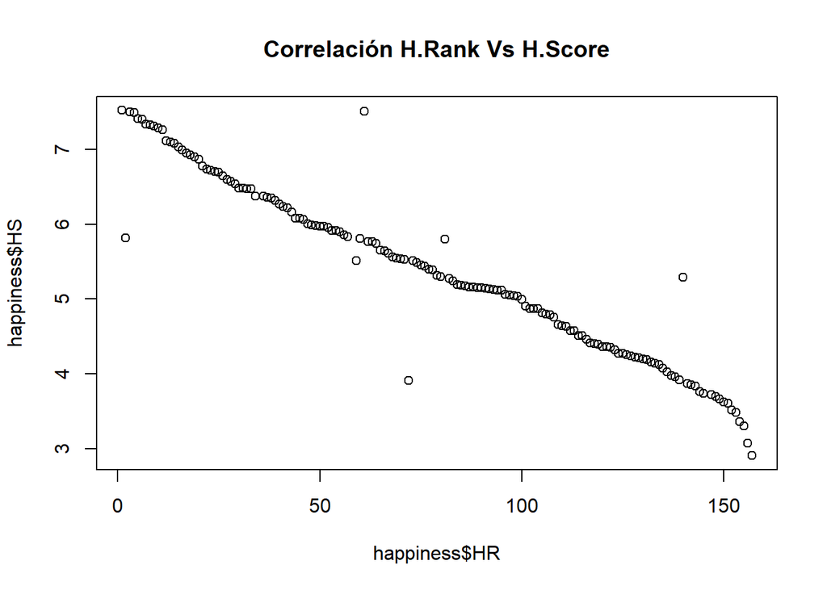

```r
plot(x=happiness$HR, y=happiness$HS, main="Correlación H.Rank Vs H.Score")
```

#### 1. Vemos una inconsistencia clara entre ambas variables, hay valores que no siguen la correlación directa. (Todos esos puntos que se distancian de la recta de correlación.) Para solucionar esta inconsistencia vamos a realizar lo siguiente:

- Hacemos un sort del dataframe segun la variable HS y cambiamos los valores de HR con un vector c(1:nrow(happiness)). Donde nrow(happiness) es el número de filas del dataframe.

```r
happiness <- happiness[order(happiness$HS, decreasing = TRUE),]
head(happiness)
```

```
      Country         Region HR    HS   LCI   UCI     GpC  Family      LE
1     Denmark Western Europe  1 7.526 7.460 7.592 1.44178 1.16374 0.79504
2 Switzerland Western Europe 61 7.509 7.428 7.590 1.52733 1.14524 0.86303
3     Iceland Western Europe  3 7.501 7.333 7.669 1.42666      NA 0.86733
4      Norway Western Europe  4 7.498 7.421 7.575 1.57744 1.12690 0.79579
5     Finland Western Europe  5 7.413 7.351 7.475 1.40598 1.13464 0.81091
6      Canada  North America  6 7.404 7.335 7.473 1.44015 1.09610 0.82760
  Freedom      GC Generosity
1 0.57941 0.44453    0.36171
2 0.58557 0.41203    0.28083
3 0.56624 0.14975    0.47678
4 0.59609 0.35776    0.37895
5 0.57104 0.41004    0.25492
6 0.57370 0.31329    0.44834
```

```r
happiness$HR <- c(1:nrow(happiness))
head(happiness)
```

```
      Country         Region HR    HS   LCI   UCI     GpC  Family      LE
1     Denmark Western Europe  1 7.526 7.460 7.592 1.44178 1.16374 0.79504
2 Switzerland Western Europe  2 7.509 7.428 7.590 1.52733 1.14524 0.86303
3     Iceland Western Europe  3 7.501 7.333 7.669 1.42666      NA 0.86733
4      Norway Western Europe  4 7.498 7.421 7.575 1.57744 1.12690 0.79579
5     Finland Western Europe  5 7.413 7.351 7.475 1.40598 1.13464 0.81091
6      Canada  North America  6 7.404 7.335 7.473 1.44015 1.09610 0.82760
  Freedom      GC Generosity
1 0.57941 0.44453    0.36171
2 0.58557 0.41203    0.28083
3 0.56624 0.14975    0.47678
4 0.59609 0.35776    0.37895
5 0.57104 0.41004    0.25492
6 0.57370 0.31329    0.44834
```

De este modo ahora, el valor de HR es totalmente dependiente del valor de HS y si volvemos a graficarlos mediante un Scatterplot vemos como la dependencia y por lo tanto la correlación ya no tiene valores outliers.

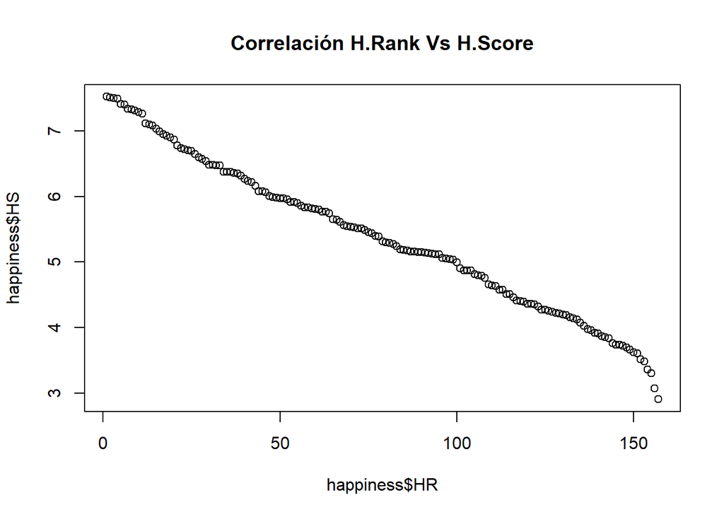

```
[1] "2, 35, 58, 59, 61, 72, 81, 140, 146"
```

```r
plot(x=happiness$HR, y=happiness$HS, main="Correlación H.Rank Vs H.Score")
```

## 4.2 LCI Vs UCI

Volvemos a hacer lo mismo, entendemos los valores de cada categoría:

1. LCI → Lower.Confidence.Interval: Límite inferior del intervalo de confianza de la media de Happiness.Score.
2. UCI → Upper.Confidence.Interval: Límite superior del intervalo de confianza de la media de Happiness.Score.

En este caso identificamos que el LCI siempre debería ser menor o igual que el UCI, en caso contrario, los datos no deberían ser correctos.

Procedemos a analizar los valores de las categorías en cuestión y nos damos cuenta de que:

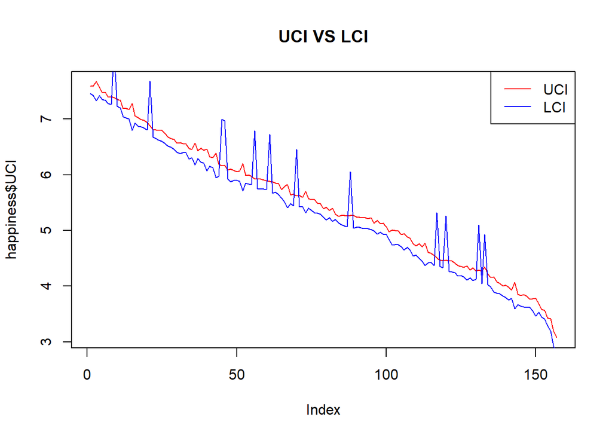

```r
plot(happiness$UCI, type="l", col ="red", main = "UCI VS LCI")
lines(happiness$LCI, type = "l", col = "blue")
legend("topright", legend=c("UCI", "LCI"), col = c("red", "blue"), lty = 1)
```

Como podemos observar en este gráfico, existen ciertos paises en los que podemos ver un cruce de información y lo que sería el UCI pasa a ser el LCI y viceversa.

Para resolver esta incosistencia, debemos identificar en qué registros sucede y cambiar los valores:

Mediante un *which()* detectamos en qué valores del índice el valor de LCI es mayor que UCI.

```r
LCIgtUCI <- which(happiness$LCI>happiness$UCI)
LCIgtUCI
```

```
 [1]   9  21  45  46  56  61  70  88 117 120 131 133
```

Seleccionamos esos valores del índice y le decimos que cambie los valores de UCI a LCI y viceversa:

```r
happiness[LCIgtUCI, c("LCI", "UCI")] <- happiness[LCIgtUCI, c("UCI", "LCI")]
```

Volvemos a graficar para asegurarnos que la inconsistencia ha desaparecido:

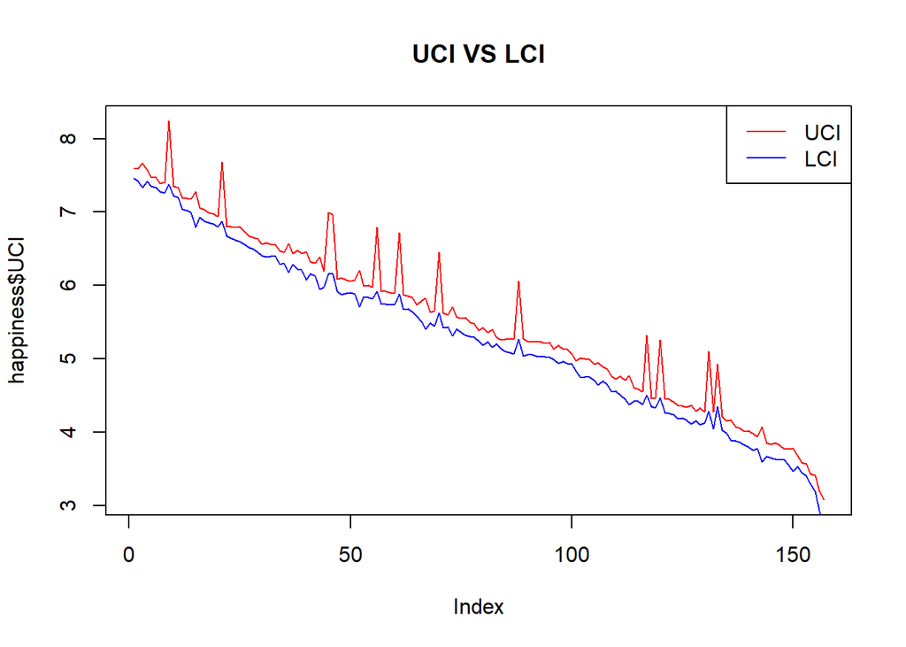

```r
plot(happiness$UCI, type="l", col ="red", main = "UCI VS LCI")
lines(happiness$LCI, type = "l", col = "blue")
legend("topright", legend=c("UCI", "LCI"), col = c("red", "blue"), lty = 1)
```

# 5. Valores atípicos

## 5.1 Revisar si hay valores atípicos en las variables HS, GC, Generosity y Family.

Para graficar e identificar valores atípicos en las variables en cuestión, vamos a usar ggplot2. Por eso tenemos que cargar la libreria

```r
library(ggplot2)
```

### Variable HS → Happiness.Score

Primero identificamos el rango de valores aceptados de la variable. En este caso el rango es 1 a 10.

Identificamos el rango de valores real en la variable:

```r
summary(happiness$HS)
```

```
   Min. 1st Qu.  Median    Mean 3rd Qu.    Max.
  2.905   4.404   5.314   5.382   6.269   7.526
```

Como observamos los valores que identificamos en el dataset forman parte del rango de valores aceptado.

Además la función de densidad de la variable se concentra en un rango aceptable

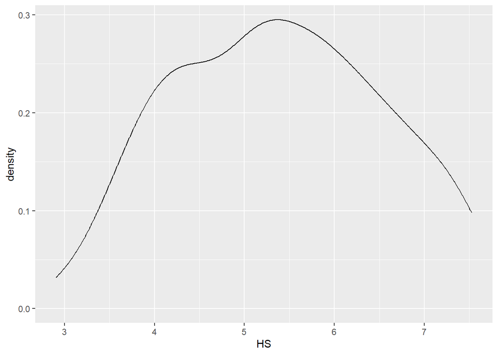

```r
ggplot(happiness, aes(x=HS)) + geom_density()
```

Para identificar valores atípicos, utilizaremos los gráficos boxplot que como nos dice la teoria, un valor atípico es aquel que es representado como puntos extremos alejados de los “bigotes” o segmentos exteriores de la caja. Los “bigotes” se extienden hasta los valores mínimo y máximo de la serie de datos o hasta 1.5 veces el Rango intercuartílico (IQR).

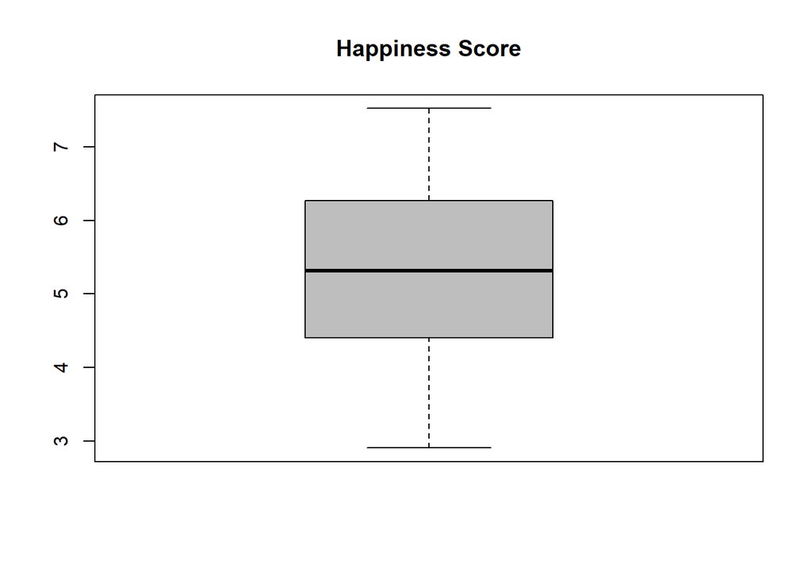

```r
boxplot(happiness$HS, main="Happiness Score", col = "gray")
```

Como podemos observar, el boxplot nos indíca que en la variable **HS** todos los valores se encuentran dentro del rango de +-1.5*IQR, por lo tanto podemos decir con certeza que no hay valores atípicos en esta variable.

### Variable GC → Government.Corruption

Volvemos a hacer el mismo proceso. Primero identificamos el rango de valores aceptados para la variable GC. Éste sería el resultado de una respuesta binaria es decir, comprenderemos el rango aceptado entre 0 y 1.

De este modo, identificamos el rango de valores real en la variable:

```r
summary(happiness$GC)
```

```
   Min. 1st Qu.  Median    Mean 3rd Qu.    Max.
0.00000 0.06126 0.10547 0.13762 0.17554 0.50521
```

Como observamos los valores que identificamos en el dataset forman parte del rango de valores aceptado.

La función de densidad de la variable se concentra en un rango aceptable con tendencia a dejar una larga cola por el extremo derecho, lo que nos indica que hay unos pocos paises con tendencia a tener gobiernos corruptos, pero siempre dentro de un rango aceptado.

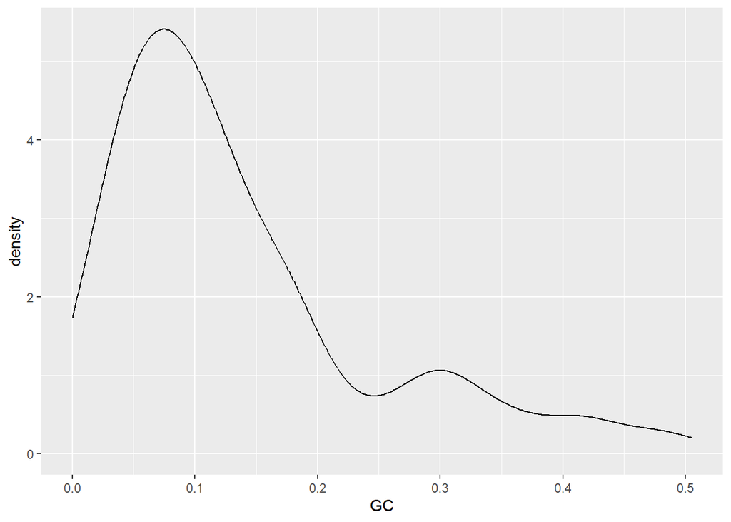

```r
ggplot(happiness, aes(x=GC)) + geom_density()
```

Procedemos a analizar si existen valores atípicos basándonos en el gráfico boxplot:

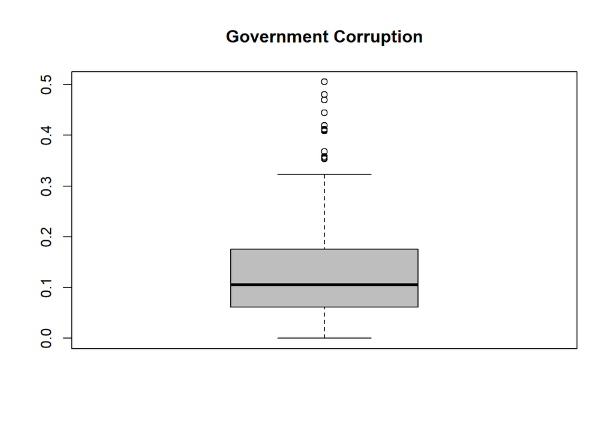

```r
boxplot(happiness$GC, main="Government Corruption", col = "gray")
```

En este caso podemos ver como esa larga cola en el extremo derecho de la función de densidad se traduce en una serie de valores atípicos cuando dibujamos el boxplot.

Identificamos estos valores atípicos mediante la función boxplot.stats()$out:

```r
GC.Out <- boxplot.stats(happiness$GC)$out
length(GC.Out)
```

```
[1] 12
```

Vemos que son 12 valores que pertenecen a los siguientes países:

```r
GC.Out.Index <- which(happiness$GC %in% c(GC.Out))
happiness[GC.Out.Index,]
```

```
                 Country                          Region  HR    HS   LCI   UCI
1                Denmark                  Western Europe   1 7.526 7.460 7.592
2            Switzerland                  Western Europe   2 7.509 7.428 7.590
4                 Norway                  Western Europe   4 7.498 7.421 7.575
5                Finland                  Western Europe   5 7.413 7.351 7.475
8            New Zealand       Australia and New Zealand   8 7.334 7.264 7.404
10                Sweden                  Western Europe  10 7.291 7.227 7.355
20            Luxembourg                  Western Europe  20 6.871 6.804 6.938
22             Singapore               Southeastern Asia  22 6.739 6.674 6.804
28  United Arab Emirates Middle East and Northern Africa  28 6.573 6.494 6.652
36                 Qatar Middle East and Northern Africa  36 6.375 6.178 6.572
97     Somaliland Region              Sub-Saharan Africa  97 5.057 4.934 5.180
152               Rwanda              Sub-Saharan Africa 152 3.515 3.444 3.586
          GpC  Family      LE Freedom      GC Generosity
1     1.44178 1.16374 0.79504 0.57941 0.44453    0.36171
2     1.52733 1.14524 0.86303 0.58557 0.41203    0.28083
4     1.57744 1.12690 0.79579 0.59609 0.35776    0.37895
5     1.40598 1.13464 0.81091 0.57104 0.41004    0.25492
8   136.06600 1.17278 0.83096 0.58147 0.41904    0.49401
10    1.45181 1.08764 0.83121 0.58218 0.40867    0.38254
20    1.69752 1.03999 0.84542 0.54870 0.35329    0.27571
22    1.64555 0.86758 0.94719 0.48770 0.46987    0.32706
28    1.57352 0.87114 0.72993 0.56215 0.35561    0.26591
36    1.82427      NA 0.71723 0.56679 0.48049    0.32388
97    0.25558 0.75862 0.33108 0.39130 0.36794    0.51479
152   0.32846 0.61586 0.31865 0.54320 0.50521    0.23552
```

En este caso, como los valores atípicos forman parte de los valores aceptados y, independientemente del país, son valores que cabría la posibilidad que fueran reales. Los aceptamos y los definimos como valor atípico pero **no anomalo**.

### Variable Generosity

Seguimos aplicando el mismo proceso. El rango de valores aceptados para la variable Generosity sería el resultado de una respuesta binaria, es decir, comprenderemos el rango aceptado entre 0 y 1.

De este modo, identificamos el rango de valores real en la variable:

```r
summary(happiness$Generosity)
```

```
   Min. 1st Qu.  Median    Mean 3rd Qu.    Max.
 0.0000  0.1546  0.2225  0.2426  0.3119  0.8197
```

Como observamos los valores que identificamos en el dataset forman parte del rango de valores aceptado, además, observamos como el valor mínimo se situa en el 0.0. En este caso, aceptamos este valor como atípico y no anomalo. Esto es porque la variable *Generosity* responde a la pregunta: ¿Ha donado o no dinero para caridad, el pasado mes? La respuesta puede ser que no, en la totalidad del país? Eso sería poco probable, pero puede suceder.

En la función de densidad de la variable generosity nos ocurre algo parecido a la de GC, los valores dejan una cola por el extremo superior, indicando que hay ciertos valores alejandose de la media en valores grandes. Aún así, son valores que forman parte del rango aceptado.

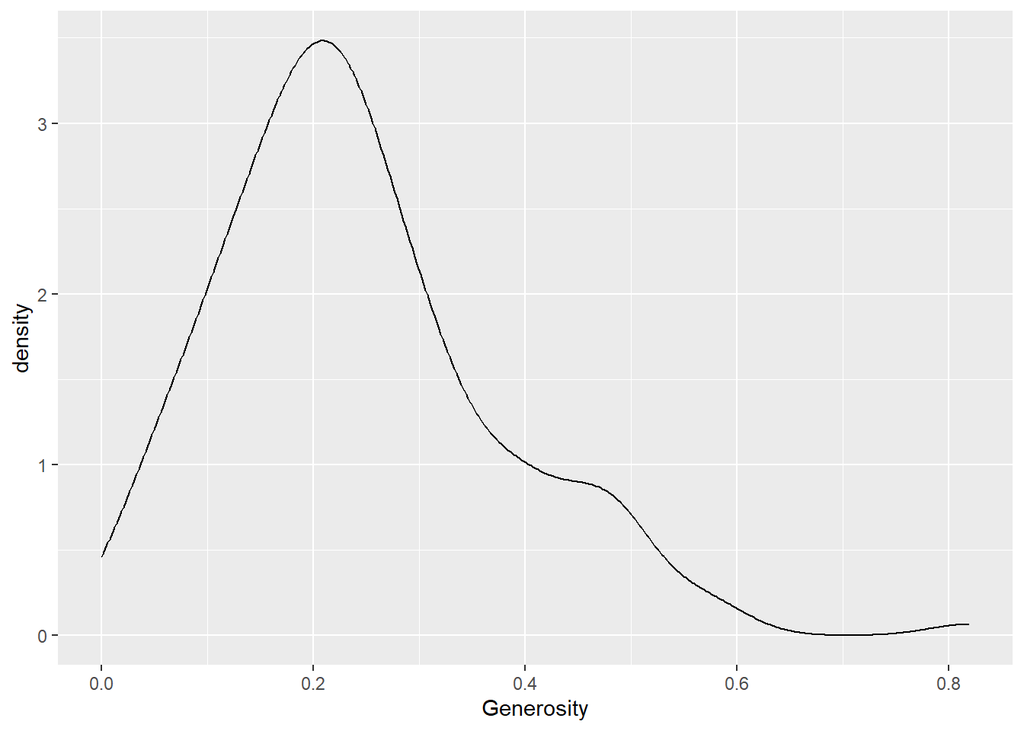

```r
ggplot(happiness, aes(x=Generosity)) + geom_density()
```

Procedemos a analizar si existen valores atípicos basándonos en el gráfico boxplot:

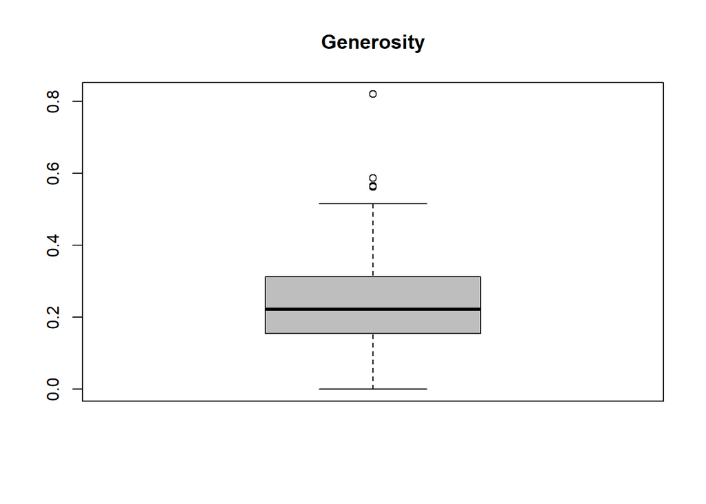

```r
boxplot(happiness$Generosity, main="Generosity", col = "gray")
```

Como bien hemos puntualizado en el párrafo anterior, existen valores atípicos por el extremo superior, pero tal y como nos sucedió en la variable GC, los aceptamos ya que forman parte de los valores aceptados y nos pueden servir para explicar ciertas tendencias y casos puntuales de la variable.

Identificamos estos valores atípicos mediante la función boxplot.stats()$out:

```r
Generosity.Out <- boxplot.stats(happiness$Generosity)$out
length(Generosity.Out)
```

```
[1] 4
```

Vemos que son 4 valores que pertenecen a los siguientes países:

```r
Generosity.Out.Index <- which(happiness$Generosity %in% c(Generosity.Out))
happiness[Generosity.Out.Index,]
```

```
      Country            Region  HR    HS   LCI   UCI     GpC  Family      LE
30      Malta    Western Europe  30 6.488 6.409 6.567 1.30782      NA 0.80315
33   Thailand Southeastern Asia  33 6.474 6.396 6.552 1.08930 1.04477 0.64915
79  Indonesia Southeastern Asia  79 5.314 5.237 5.391 0.95104 0.87625 0.49374
119   Myanmar Southeastern Asia 119 4.395 4.327 4.463 0.34112 0.69981 0.39880
    Freedom      GC Generosity
30  0.54994 0.17554    0.56237
33  0.49553 0.02833    0.58696
79  0.39237 0.00322    0.56521
119 0.42692 0.20243    0.81971
```

Por tanto, para la variable *Generosity* aceptamos los valores atípicos como no anómalos.

### Variable Family

Identificamos el rango de valores aceptados de la variable como una respuesta a la pregunta ¿tiene familiares o amigos con los que pueda contar? Siendo las posibles respuestas 0,1 y 2.

Identificamos el rango de valores real en la variable:

```r
summary(happiness$Family)
```

```
   Min. 1st Qu.  Median    Mean 3rd Qu.    Max.    NA's
 0.0000  0.6361  0.8322  0.7854  1.0058  1.1728       5
```

Como observamos los valores que identificamos en el dataset forman parte del rango de valores aceptado. Aunque siendo críticos y conscientes del significado de la variable, debemos tener algo en cuenta: Es posible que la media de un país situe la respuesta a esta pregunta en 0? Es decir, ¿nadie, en un país entero, tiene familiares y amigos? En este caso entendemos que el extremo 0 de esta respuesta como media de un país no debería ser aceptado ya que la muestra seleccionada de ese país concreto no es representativa de la imagen del país. Procederemos a tratar este valor atípico.

La función de densidad de la variable se concentra en un rango aceptable:

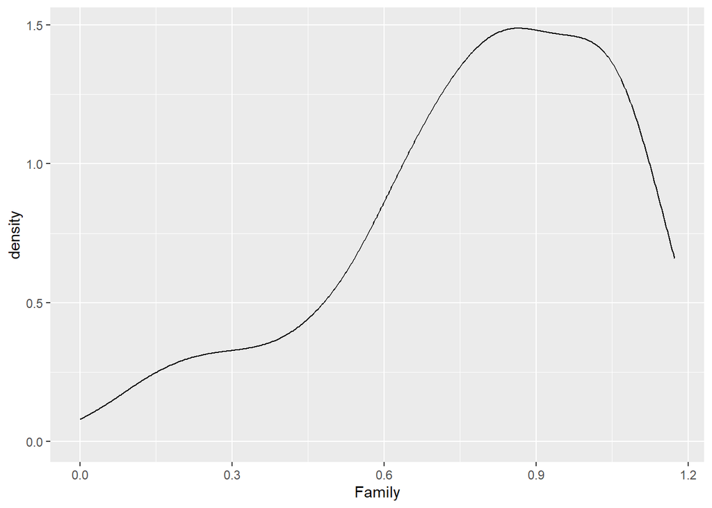

```r
ggplot(happiness, aes(x=Family)) + geom_density()
```

En este caso, vemos que la función de densidad nos muestra un gráfico contrario a los anteriores. Vemos una cola en el extremo inferior empezando en el 0. Aún así, el rango de datos se encuentra dentro de los valores aceptados, menos el 0 que será tratado posteriormente.

Analizamos si existen valores atípicos basándonos en el grafico boxplot:

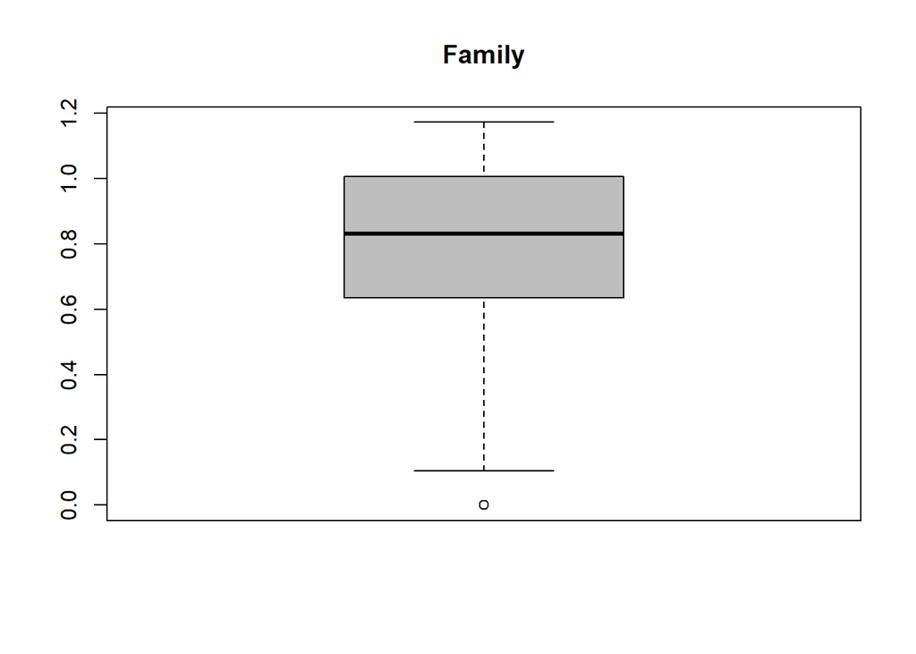

```r
boxplot(happiness$Family, main="Family", col = "gray")
```

Observamos que como bien hemos analizado, el valor 0 se encuentra fuera del rango +- 1.5*IQR por lo que lo definimos como valor atípico.

Identificamos estos valores atípicos mediante la función boxplot.stats()$out:

```r
Family.Out <- boxplot.stats(happiness$Family)$out
length(Family.Out)
```

```
[1] 1
```

Vemos que hay un solo valor que pertenece al siguiente país:

```r
Family.Out.Index <- which(happiness$Family %in% c(Family.Out))
happiness[Family.Out.Index,]
```

```
    Country             Region  HR    HS   LCI   UCI     GpC Family      LE
155    Togo Sub-Saharan Africa 155 3.303 3.192 3.414 0.28123      0 0.24811
    Freedom      GC Generosity
155 0.34678 0.11587    0.17517
```

Como bien hemos ido comentando, el valor atípico en cuestión si que se trataría de un valor anómalo por probabilidad. Así que procedemos a tratarlo como NA.

Para hacerlo usamos la función **replace()**

```r
happiness$Family <- replace(happiness$Family, happiness$Family == 0, NA)
happiness[Family.Out.Index,]
```

```
    Country             Region  HR    HS   LCI   UCI     GpC Family      LE
155    Togo Sub-Saharan Africa 155 3.303 3.192 3.414 0.28123     NA 0.24811
    Freedom      GC Generosity
155 0.34678 0.11587    0.17517
```

El valor de Family para el país Togo ahora aparece como *NA*.

Al volver a graficar el boxplot vemos que ya no nos aparece el valor atípico de Togo:

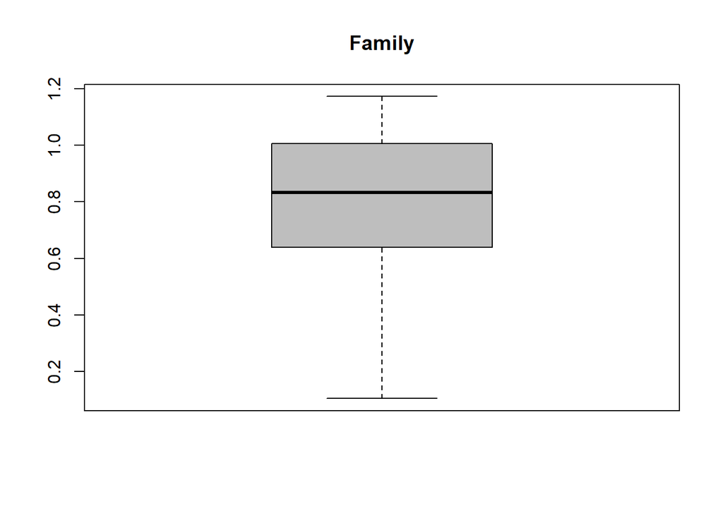

```r
boxplot(happiness$Family, main="Family", col = "gray")
```

# 6. Imputación de valores

En este ejercicio y, tal como nos indica el enunciado, utilizaremos la **distancia de Gower** para la alicación de valor a los valores perdidos(NAs), para su aplicación, usaremos la función **kNN()** del paquete **VIM**:

Para ello, procedemos a instalar y cargar la librería VIM:

```r
# install.packages("VIM")
library("VIM")
```

Cuando analizamos la variable Family, nos damos cuenta que hay una serie de valores perdidos, en total son 6. Esto lo podemos ver usando la función **which()** junto con **is.na()**, así veremos los índices de los valores con valores perdidos en la variable Family.

Los valores perdidos corresponden a los siguientes paises:

```r
is_na_family.index <- which(is.na(happiness$Family))
happiness[is_na_family.index,]
```

```
        Country                          Region  HR    HS   LCI   UCI     GpC
3       Iceland                  Western Europe   3 7.501 7.333 7.669 1.42666
7   Netherlands                  Western Europe   7 7.339 7.284 7.394 1.46468
30        Malta                  Western Europe  30 6.488 6.409 6.567 1.30782
36        Qatar Middle East and Northern Africa  36 6.375 6.178 6.572 1.82427
44    Venezuela     Latin America and Caribbean  44 6.084 5.973 6.195 1.13367
155        Togo              Sub-Saharan Africa 155 3.303 3.192 3.414 0.28123
    Family      LE Freedom      GC Generosity
3       NA 0.86733 0.56624 0.14975    0.47678
7       NA 0.81231 0.55211 0.29927    0.47416
30      NA 0.80315 0.54994 0.17554    0.56237
36      NA 0.71723 0.56679 0.48049    0.32388
44      NA 0.61904 0.19847 0.08304    0.04250
155     NA 0.24811 0.34678 0.11587    0.17517
```

Mediante la formula kNN() y un número “k” de vecinos igual a 11, convertimos los valores perdidos de la variable Family:

```r
happiness.completo <- kNN(data=happiness, variable="Family", k=11)
summary(happiness.completo)
```

```
   Country                                      Region         HR
 Length:157         Sub-Saharan Africa             :38   Min.   :  1
 Class :character   Central and Eastern Europe     :29   1st Qu.: 40
 Mode  :character   Latin America and Caribbean    :24   Median : 79
                    Western Europe                 :21   Mean   : 79
                    Middle East and Northern Africa:19   3rd Qu.:118
                    Southeastern Asia              : 9   Max.   :157
                    (Other)                        :17
       HS             LCI             UCI             GpC
 Min.   :2.905   Min.   :2.732   Min.   :3.078   Min.   :  0.0000
 1st Qu.:4.404   1st Qu.:4.371   1st Qu.:4.609   1st Qu.:  0.6702
 Median :5.314   Median :5.267   Median :5.483   Median :  1.0278
 Mean   :5.382   Mean   :5.298   Mean   :5.543   Mean   :  7.9520
 3rd Qu.:6.269   3rd Qu.:6.169   3rd Qu.:6.471   3rd Qu.:  1.3186
 Max.   :7.526   Max.   :7.460   Max.   :8.241   Max.   :150.7960

     Family             LE            Freedom             GC
 Min.   :0.1042   Min.   :0.0000   Min.   :0.0000   Min.   :0.00000
 1st Qu.:0.6418   1st Qu.:0.3829   1st Qu.:0.2575   1st Qu.:0.06126
 Median :0.8414   Median :0.5966   Median :0.3975   Median :0.10547
 Mean   :0.7966   Mean   :0.5576   Mean   :0.3710   Mean   :0.13762
 3rd Qu.:1.0141   3rd Qu.:0.7299   3rd Qu.:0.4845   3rd Qu.:0.17554
 Max.   :1.1728   Max.   :0.9528   Max.   :0.6085   Max.   :0.50521

   Generosity     Family_imp
 Min.   :0.0000   Mode :logical
 1st Qu.:0.1546   FALSE:151
 Median :0.2225   TRUE :6
 Mean   :0.2426
 3rd Qu.:0.3119
 Max.   :0.8197
```

Copiamos la nueva info de la variable Family a nuestro dataset original y comprobamos que no hay más NA en la variable Family.

```r
happiness$Family <- happiness.completo$Family
is_na_family.index
```

```
[1]   3   7  30  36  44 155
```

Para comprobar el nuevo valor de los antiguos valores perdidos lo podemos hacer de la siguiente forma:

```r
happiness[is_na_family.index,]
```

```
        Country                          Region  HR    HS   LCI   UCI     GpC
3       Iceland                  Western Europe   3 7.501 7.333 7.669 1.42666
7   Netherlands                  Western Europe   7 7.339 7.284 7.394 1.46468
30        Malta                  Western Europe  30 6.488 6.409 6.567 1.30782
36        Qatar Middle East and Northern Africa  36 6.375 6.178 6.572 1.82427
44    Venezuela     Latin America and Caribbean  44 6.084 5.973 6.195 1.13367
155        Togo              Sub-Saharan Africa 155 3.303 3.192 3.414 0.28123
     Family      LE Freedom      GC Generosity
3   1.09774 0.86733 0.56624 0.14975    0.47678
7   1.09774 0.81231 0.55211 0.29927    0.47416
30  1.08672 0.80315 0.54994 0.17554    0.56237
36  0.94397 0.71723 0.56679 0.48049    0.32388
44  0.85974 0.61904 0.19847 0.08304    0.04250
155 0.60530 0.24811 0.34678 0.11587    0.17517
```

# 7. Estudio descriptivo

## 7.1 Representación gráfica de variables

Antes que nada, calculamos las medias de Freedom para cada región y las colocamos en un dataframe usando **aggregate()**:

```r
FreedombyRegion <- aggregate(Freedom ~ Region, data = happiness, mean)
FreedombyRegion
```

```
                            Region   Freedom
1        Australia and New Zealand 0.5749200
2       Central and Eastern Europe 0.3005283
3                     Eastern Asia 0.3872817
4      Latin America and Caribbean 0.4266463
5  Middle East and Northern Africa 0.3097689
6                    North America 0.5276650
7                Southeastern Asia 0.4901233
8                    Southern Asia 0.3500257
9               Sub-Saharan Africa 0.3154242
10                  Western Europe 0.4775871
```

Una vez tenemos el dataframe listo procedemos a crear la visualización, procedemos a elegir un barplot. El motivo es sencillo, como se trata de la comparación de valores entre categorías nominales, lo mejor es visualizarlo de la forma más sencilla mediante barras.

Como las categorías tienen nombres largos, colocaremos en el eje X la variable numérica (Freedom), y en la Y la variable categorica, de este modo, tendremos más espacio en el gráfico entero.

Usaremos la función reorder donde le indicaremos que queremos ordenar la variable región en función de Freedom (de mayor a menor).

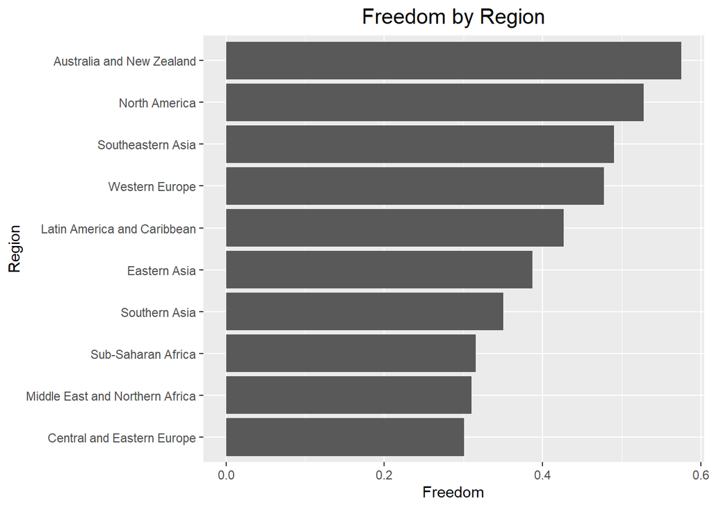

```r
barplot_7.1 <- ggplot(FreedombyRegion, aes(x=Freedom , y=reorder(Region, Freedom))) +
  geom_bar(stat="identity") + ggtitle("Freedom by Region") +
  labs(x="Freedom", y = "Region") +
  theme(plot.title = element_text(hjust=0.5, size = 15))
barplot_7.1
```

## 7.2 Medidas características

Tomaremos como medidas las del esquema general de los apuntes “Preprocesamiento de los datos” página 25.

Para calcular la media winsorizada necesitaremos cargar la libreria **psych**:

```r
library("psych")
```

Creamos un vector con las variables cuantitativas correspondientes y la formula que la genera, mediante la función sapply.

A los valores de cada agregación los redondeamos a 3 decimales, de este modo queda mucho más pulcro y se pueden seguir viendo las diferencias, para aplicar esto usaremos la función **round()**.

```r
mean <- round(sapply(happiness[ , c('HS', 'LCI', 'UCI', 'GpC', 'Family', 'LE', 'Freedom', 'GC', 'Generosity')], mean), 3)
median <- round(sapply(happiness[ , c('HS', 'LCI', 'UCI', 'GpC', 'Family', 'LE', 'Freedom', 'GC', 'Generosity')], median), 3)
trimmed_mean <- round(sapply(happiness[ , c('HS', 'LCI', 'UCI', 'GpC', 'Family', 'LE', 'Freedom', 'GC', 'Generosity')], function(x) mean(x, trim = 0.05)), 3)
winsor_mean <- round(sapply(happiness[ , c('HS', 'LCI', 'UCI', 'GpC', 'Family', 'LE', 'Freedom', 'GC', 'Generosity')], function(x) winsor.mean(x, trim=0.05)), 3)
sd <- round(sapply(happiness[ , c('HS', 'LCI', 'UCI', 'GpC', 'Family', 'LE', 'Freedom', 'GC', 'Generosity')], sd), 3)
IQR <- round(sapply(happiness[ , c('HS', 'LCI', 'UCI', 'GpC', 'Family', 'LE', 'Freedom', 'GC', 'Generosity')], IQR), 3)
mad <- round(sapply(happiness[ , c('HS', 'LCI', 'UCI', 'GpC', 'Family', 'LE', 'Freedom', 'GC', 'Generosity')], mad), 3)
```

Separamos las medidas de tendencia central de las de dispersión y las colocamos en un DataFrame.

```r
central_tendency <- data.frame(mean, median, trimmed_mean, winsor_mean)
central_tendency
```

```
            mean median trimmed_mean winsor_mean
HS         5.382  5.314        5.382       5.391
LCI        5.298  5.267        5.297       5.308
UCI        5.543  5.483        5.542       5.546
GpC        7.952  1.028        2.482       6.856
Family     0.797  0.841        0.810       0.799
LE         0.558  0.597        0.565       0.560
Freedom    0.371  0.397        0.376       0.373
GC         0.138  0.105        0.129       0.135
Generosity 0.243  0.222        0.237       0.240
```

```r
dispersion <- data.frame(sd, IQR, mad)
dispersion
```

```
               sd   IQR   mad
HS          1.142 1.865 1.371
LCI         1.148 1.798 1.337
UCI         1.164 1.862 1.438
GpC        28.619 0.648 0.492
Family      0.259 0.372 0.282
LE          0.229 0.347 0.248
Freedom     0.146 0.227 0.166
GC          0.111 0.114 0.079
Generosity  0.134 0.157 0.116
```

# 8 Archivo final

```r
write.csv(happiness, 'pedreno_fichero_clean.csv')
```

# 9. Resumen Ejecutivo

Resumen del preprocesamiento

ID

Row

Message

1

n.row = 157; n.col = 12; n.var num = 8; n.var cualit = 4

2

Cambiamos el nombre de las variables Happiness.Rank, Happiness.Score, GDP.per.Capita, ife.Expectancy, Government Corruption, Lower.Confidence.Interval y Upper.Confidence.Interval por las mayúsculas de sus iniciales.

2

2, 9, 27, 35, 44, 48, 52, 59, 61, 72, 114, 117, 121, 140, 156

Variable HS (Happiness.Score): Cambiamos la coma como separador decimal por un punto.

2

Variable HS (Happiness.Score): Cambiamos la variable de character a numeric.

2

8, 9, 13, 24, 31, 35, 46, 67, 73, 86, 89, 98, 102, 105, 106, 113, 127, 133, 141, 142, 147, 148, 157

Variable GpC (GDP.per.Capita): Cambiamos la coma como separador decimal por un punto.

3

1, 4, 5, 6, 8, 9, 11, 27, 30, 31, 33, 34, 35, 39, 42, 44, 45, 49, 51, 53, 54, 56, 57, 60, 64, 65, 66, 67, 68, 70, 72, 74, 76, 81, 83, 84, 85, 86, 88, 89, 90, 91, 92, 93, 94, 96, 97, 104, 107, 108, 109, 110, 120, 121, 124, 125, 126, 134, 138, 140, 141, 143, 144, 145, 146, 150, 151, 152, 153, 154

Variable Country: Eliminar los espacios en blanco de inicio y final de palabra.

3

Variable Country: Capitalizar las palabras de cada país

3

1, 2, 3, 4, 5, 7, 15, 16, 18, 21, 24, 25, 27, 28, 29, 30, 31, 32, 35, 36, 44, 46, 47, 49, 52, 53, 55, 56, 58, 60, 61, 62, 63, 65, 66, 67, 70, 71, 72, 73, 74, 77, 78, 81, 83, 87, 88, 89, 90, 91, 92, 96, 97, 98, 99, 102, 103, 104, 106, 107, 109, 111, 112, 117, 119, 120, 121, 122, 123, 126, 127, 128, 129, 131, 134, 137, 141, 142, 143, 144, 148, 149, 150, 151, 153, 155, 156, 157

Variable Region: Eliminar los espacios en blanco de inicio y final de palabra.

3

28, 66, 67, 78, 106, 111, 112, 122, 128, 134, 137, 142, 143, 149, 151, 153, 156, 157

Variable Region: Cambiamos la palabra AFRCA por AFRICA.

3

Variable Region: Capitalizar las palabras de cada región.

3

Variable Region: Cambiar ‘AND’ o ‘And’ por ‘and’.

3

Variable Region: Cambiar el tipo de variable de Character a Factor.

4

9, 21, 45, 46, 56, 61, 70, 88, 117, 120, 131, 133

5

155

Variable Family : Detección de valores anómalos y cambio a NA.

6

3, 7, 30, 36, 44, 155

Variable Family : Detección de valores perdidos e imputación de valor basandonos en la distancia de Glower con 11 vecinos.

8

n.row = 157; n.col = 12; n.var num = 10; n.var cualit = 2

## 9.2 Resumen estadístico

# Apéndice: Bibliografía

1. Uso de la función sub()
2. [Convertir de character a numeric](https://statisticsglobe.com/convert-character-to-numeric-in-r/)
3. [Poner primera letra en mayúscula](https://www.geeksforgeeks.org/convert-first-letter-of-every-word-to-uppercase-in-r-programming-str_to_title-function/)
4. Función str_squish
5. [Función Order](https://www.rdocumentation.org/packages/base/versions/3.6.2/topics/order)
6. Función Which
7. [Cambiar valores entre columnas](https://stackoverflow.com/questions/5724419/is-it-possible-to-swap-columns-around-in-a-data-frame-using-r)
8. [Scatterplot](https://www.statmethods.net/graphs/scatterplot.html)
9. [Gráfico con 2 lineas](https://r-coder.com/grafico-lineas-r/)
10. Boxplot
11. Función Replace()
12. [Comments y Warning en rmd](https://stackoverflow.com/questions/45399587/how-to-remove-warning-messages-in-r-markdown-document)
13. [Función Reorder Barplot](https://stackoverflow.com/questions/25664007/reorder-bars-in-geom-bar-ggplot2-by-value)
14. Función Aggregate
15. [Función Trimmed mean](https://www.r-bloggers.com/2021/12/how-to-find-a-trimmed-mean-in-r/)
16. [Función Round](https://www.rdocumentation.org/packages/base/versions/3.6.2/topics/Round)
17. [Función paste0](https://statisticsglobe.com/r-paste-paste0-function-example)
18. [Función toString](https://www.rdocumentation.org/packages/base/versions/3.6.2/topics/toString)
19. [Grep con Regex](https://stackoverflow.com/questions/33555167/grep-for-a-regular-expression-in-r)
20. [Parámetro row.names](https://stackoverflow.com/questions/24428051/removing-display-of-row-names-from-data-frame)